# Fish Biodiversity Patterns

Gulf of Mexico Results

Hannah L. Owens

2026-08-27

# Readying the data

Read in data and trim occurrences to area of interest–the Gulf of Mexico.

```
## Using x and y
##  as x and y coordinates, respectively.
```

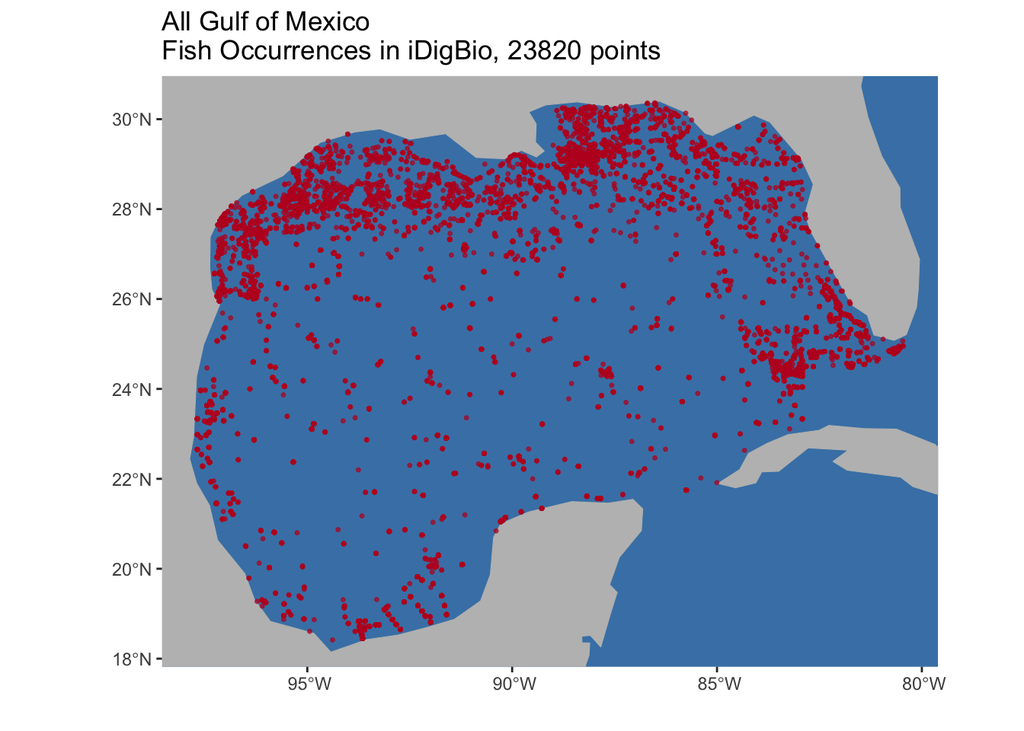

```r
fishData <- data.frame(read.csv("data/iDigBioProcessedFishOccurrences_SingerAndOwens.csv"))
fishData <- fishData |>
  select(iDigBio_dwc_decimalLongitude,
         iDigBio_dwc_decimalLatitude,
         SOcurated_depth, SOcurated_depthUncertainty,
         SOcurated_minimumDepthInMeters,
         SOcurated_maximumDepthInMeters,
         WoRMS_scientificName,
         WoRMS_family,
         SOcurated_bibliographicCitation) |>
  drop_na(iDigBio_dwc_decimalLongitude,
         iDigBio_dwc_decimalLatitude,
         SOcurated_depth, SOcurated_depthUncertainty,
         SOcurated_minimumDepthInMeters,
         SOcurated_maximumDepthInMeters,
         WoRMS_scientificName,
         WoRMS_family)

# Get rid of overland points
fishData <- vect(fishData,
                            geom = c("iDigBio_dwc_decimalLongitude",
                                     "iDigBio_dwc_decimalLatitude"))
crs(fishData) <- crs("EPSG:4326")

gomShapefile <- vect("data/GOM/GOM.shp")
gomShapefile <- project(gomShapefile, crs(fishData))
gomShapefile <- buffer(gomShapefile, 10000)
gomExtent <- ext(gomShapefile)
fishData <- crop(fishData, gomShapefile)

land <- vect(rnaturalearth::ne_countries(scale = "small",
                                         returnclass = "sf")[1])
land <- aggregate(land)
land <- project(land, crs("EPSG: 4326"))
landFish <- is.related(fishData, land, "within")
fishData <- fishData[!landFish,]

pointMap(as.data.frame(geom(fishData)),
         spName = "All Gulf of Mexico\nFish Occurrences in iDigBio",
         land = land)
```

# Mapping

First, we have to set things up by making a hexagon grid to aggregate the data. This was adapted and updated from https://strimas.com/post/hexagonal-grids/.

```r
# "EPSG:6579 NAD83(2011) / Texas-Centric Albers Equal Area"
fishData <- project(fishData, "EPSG:6579")
gomShapefile <- project(gomShapefile, crs(fishData))
land <- project(land, crs(fishData))

# Study area
studyArea <- ext(gomShapefile)
HexPols2 <- st_make_grid(studyArea ,
                         cellsize = 100000,
                         square = FALSE)
GOM <- vect(HexPols2)
crs(GOM) <- crs(land)
GOMland <- is.related(GOM, gomShapefile, "intersects")
GOM <- GOM[GOMland,]
```

## Sampling Density

How many records are there in each hexagonal cell?

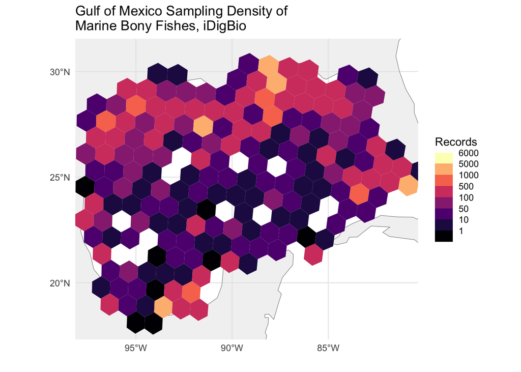

```r
# Gridding it
point_density <- terra::extract(x = GOM, y = fishData)
fishData$hexID <- point_density[,2]
point_density <- table(point_density[,2])
counts <- NULL
for ( i in 1:length(GOM)){
  if (i %in% as.numeric(names(point_density))){
    counts <- c(counts,
                point_density[names(point_density) == i])
  } else{
    counts <- c(counts, NA)
  }
}

GOM$counts <- counts

my_breaks <- c(1, 10, 50, 100, 500, 1000, 5000, 6000)
my_col <- rgb(0, 0, 255, max = 255,
              alpha = 0, names = "clear")

# pdf(file = "Figures/GOMDiversity.pdf")
ggplot() +
  geom_spatvector(data = land,
                  color = "gray50",
                  alpha = .5) +
  geom_spatvector(data = GOM,
                  aes(fill = counts),
                  color = NA) +
  scale_fill_viridis_b(name = "Records", option = "A",
                       na.value = my_col, breaks = my_breaks,
                       limits = c(0, max(my_breaks))) +
  theme_minimal() +
  coord_sf(crs = st_crs(4326), expand = TRUE,
           xlim = gomExtent[1:2], ylim = gomExtent[3:4],
           label_graticule = "SW") +
  ggtitle("Gulf of Mexico Sampling Density of\nMarine Bony Fishes, iDigBio") +
  scale_x_longitude(ticks = 5) + scale_y_latitude(ticks = 5)
```

```r
# dev.off()
```

## Depth Coverage

This map highlights regions of the ocean with differing depth coverage of sampling effort - specifically the percentage of “available depth” in each hexagon covered by records in iDigBio.

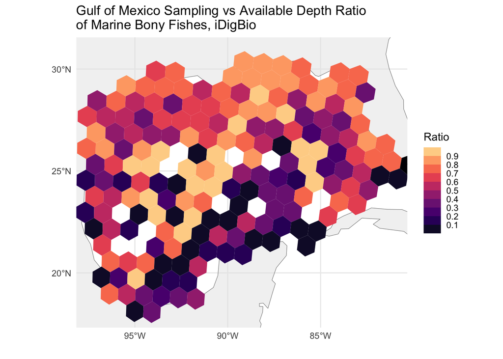

```r
# Get bathymetery
bathymetry <- rast("data/ETOPO_2022_v1_60s_N90W180_bed.tif") %>%
  crop(ext(project(GOM, crs("EPSG:4326")))) %>%
  project(crs(GOM), method = "min")
GOM$bathymetry <- terra::extract(x = bathymetry, y = GOM, fun = min)[,2]
GOM$bathymetry[GOM$bathymetry > 0] <- NA

# Get sampling depth
samplingDepth <- NULL
for (i in 1:length(GOM)){
  refs <- is.related(fishData, GOM[i], "within")
  if(any(refs)){
    maxDepth <- max(fishData[refs,"SOcurated_maximumDepthInMeters"],
                    na.rm = TRUE)
  } else {
    maxDepth <- NA
  }
  samplingDepth <- c(samplingDepth, maxDepth)
}

GOM$maxSample <- -samplingDepth
GOM$samplingRatio <- GOM$maxSample/GOM$bathymetry
GOM$samplingRatio[GOM$samplingRatio > 1] <- 1

# Put it all together
# pdf("Figures/GOMSamplingRatio.pdf")
ggplot() +
  geom_spatvector(data = land,
                  color = "gray50",
                  alpha = .5) +
  geom_spatvector(data = GOM,
                  aes(fill = samplingRatio),
                  color = NA) +
  scale_fill_viridis_b(name = "Ratio", option = "A",
                       na.value = my_col,
                       breaks = seq(0,10, by =1)/10) +
  theme_minimal() +
  coord_sf(crs = st_crs(4326), expand = TRUE,
           xlim = gomExtent[1:2], ylim = gomExtent[3:4],
           label_graticule = "SW") +
  ggtitle("Gulf of Mexico Sampling vs Available Depth Ratio\nof Marine Bony Fishes, iDigBio") +
  scale_x_longitude(ticks = 5) +
  scale_y_latitude(ticks = 5)
```

```r
# dev.off()
```

# Diversity Pattern Analyses

First, we do some additional filtering to fit the data for our use, including removing records with excessive (i.e. 100m) uncertainty in depth.

```
## [1] "Before removing records with a depth uncertainty of 100m or more, there are 23820 records."
```

```
## [1] "After removing records with a depth uncertainty of 100m or more, there are 22148 records."
```

```
## [1] "After removing records that were not identified to species, there are 20700 records."
```

Next, we assign each record to equal-width depth bins under two strategies: 1) No empty bins permitted, 2) At least 10 records per bin.

```r
# Zero empty bins
breakNumber <- 60
test <- TRUE
while (test){
    breakNumber <- breakNumber - 1
    tmp <- hist(fishData$SOcurated_depth,
                breaks = breakNumber,
                plot = F)
    test <- 0 %in% tmp$counts
}
zeroEmpty <- length(tmp$breaks)

# Minimum ten per bin
breakNumber <- 60
test <- TRUE
while (test){
    breakNumber <- breakNumber - 1
    tmp <- hist(fishData$SOcurated_depth,
                breaks = breakNumber,
                plot = F, )
    test <- 10 >= min(tmp$counts)# Checks to see if any bins are less than ten
}
tenPerBin <- length(tmp$breaks)

paste0("Number of bins if no bin can be empty: ",
       zeroEmpty)
```

```
## [1] "Number of bins if no bin can be empty: 20"
```

```r
paste0("Number of bins if each bin must have at least 10 observations: ",
       tenPerBin)
```

```
## [1] "Number of bins if each bin must have at least 10 observations: 9"
```

```r
rm(tmp, breakNumber, test)
```

## Calculate diversity statistics

Next, we define a function to calculate diversity statistics we need for downstream analysis.

```r
fishData <- data.frame(fishData)

fishData <- data.frame(fishData) |>
  filter(grepl('\\s', WoRMS_scientificName)) |> # Remove entries not ID'ed to species
  drop_na(WoRMS_scientificName)

diversityStats <- function(x, binNumber){
  # Get breaks based on equal width bins
  breaks <- seq(min(x$SOcurated_depth),
              max(x$SOcurated_depth),
              (max(x$SOcurated_depth) - min(x$SOcurated_depth))/(binNumber))

  # Species richness per bin
  depthDiversityCount <- NULL
  effort <- NULL
  for(i in 2:length(breaks)){
    temp <- x %>% filter(SOcurated_depth >= breaks[i-1],
                         breaks[i] >= SOcurated_depth)
    depthDiversityCount <- c(depthDiversityCount,
                             length(unique(temp$WoRMS_scientificName)))
    effort <- c(effort, nrow(temp))
  }
  x$SOcurated_depthBin <- cut(x$SOcurated_depth, breaks=breaks,
                    labels = paste0(round(breaks[-(binNumber+1)],
                                          digits = 0), " to ",
                                    round(breaks[-1],
                                          digits = 0)))

  # Compile data -- Spp are columns, sites are rows, counts are cells
  depthComm <- data.frame(table(data.frame(x[c("SOcurated_depth",
                                               "WoRMS_scientificName")])))
  depthComm <- as.data.frame.matrix(xtabs(Freq ~ SOcurated_depth + WoRMS_scientificName,
                                          depthComm))
  diversityResults <- data.frame(row.names = row.names(depthComm))
  diversityResults$bin <- seq(1, nrow(depthComm))

  # Calculate dissimilarity among depth bands
  depthComm.pa <- decostand (depthComm, method = 'pa')
  dis <- vegdist(depthComm, "chao") # Tries to account for unseen species pairs

  # Calculate clustering
  clust.res<-hclust(dis, "ward.D2")
  clus_cut <- cutree (clust.res, k = 2)
  phi <- multipatt (depthComm.pa,
                    cluster = clus_cut,
                    fun = 'r.g')
  phi$sign <- phi$sign[complete.cases(phi$sign),]
  re <- phi$sign[phi$sign$p.value<=0.01,]

  # Ordinate and prepare for plotting
  mds <- cmdscale(dis, eig = TRUE)
  mds$species <- wascores(mds$points,
                          depthComm,
                          expand = TRUE)
  pl <- ordiplot(mds, disp = "sites",
                 type = "none")
  if (binNumber > 2){
    clusters <- kmeans(dis, centers = 2)
    depthCluster <- as.factor(clusters$cluster)
  } else {
    clusters <- kmeans(dis, centers = 1)
    depthCluster <- as.factor(clusters$cluster)
  }

  sites.long <- BiodiversityR::sites.long(pl,
                                          env.data = depthCluster)
  sites.long[, 2:3] <- sapply(sites.long[, 2:3],
                              as.numeric)
  env.data <- as.factor(depthCluster)
  axis.long <- BiodiversityR::axis.long(mds,
                                        choices=c(1, 2),
                                        cmdscale.model = T)
  centroids.long <- BiodiversityR::centroids.long(y = sites.long,
                                                  grouping=env.data,
                                                  FUN = "median")

  # Put together all the useful outputs
  out <- list("breaks" = breaks,
              "depthDiversityCount" = depthDiversityCount,
              "effort" = effort, "data" = x,
              "binNumber" = binNumber, "depthComm" = depthComm,
              "dis" = dis, "clust.res" = clust.res,
              "clusters" = clusters, "spClusters" = re,
              "env.data" = env.data, "sites.long" = sites.long,
              "axis.long" = axis.long,
              "centroids.long" = centroids.long)
  return(out)
}

# Do the calculations
zeroEmpty <- diversityStats(x = fishData, binNumber = zeroEmpty)
```

```r
tenPerBin <- diversityStats(x = fishData, binNumber = tenPerBin)
```

## Species richness vs depth

For each binning strategy, we initially plotted diversity at depth. We include lines at 200m and 1000m, which are commonly-used boundaries for epipelagic and mesopelagic zone boundaries, respectively.

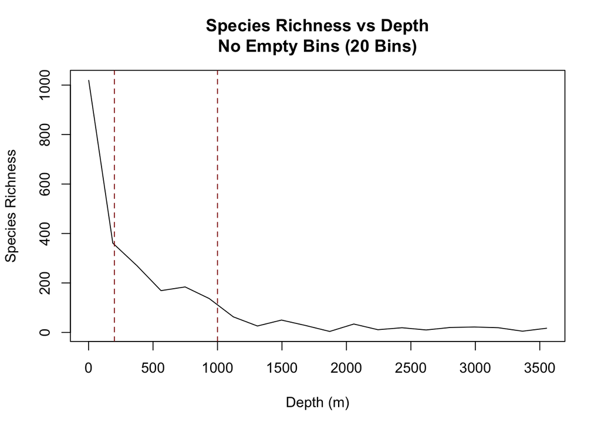

```r
# Plot diversity by depth
plot(cbind(zeroEmpty$breaks[-(length(zeroEmpty$breaks))],
           zeroEmpty$depthDiversityCount),
     type = "l", xlab = "Depth (m)", ylab = "Species Richness",
     main = paste0("Species Richness vs Depth\nNo Empty Bins (",
                   zeroEmpty$binNumber, " Bins)"))
abline(v = 200, col = "darkred", lty = "dashed")
abline(v = 1000, col = "darkred", lty = "dashed")
```

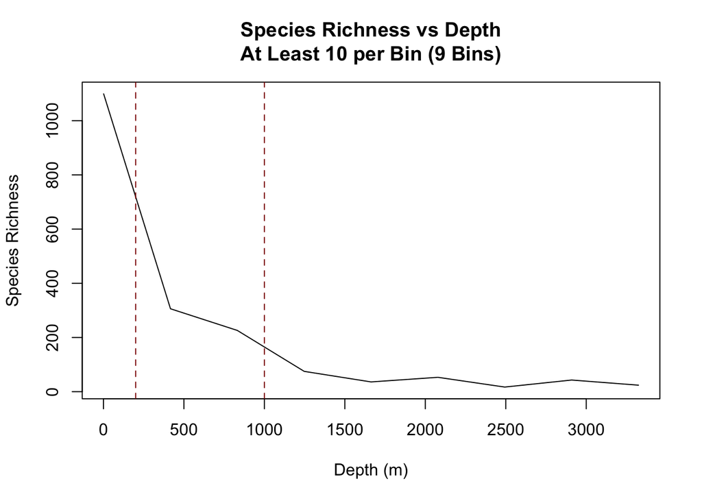

```r
plot(cbind(tenPerBin$breaks[-(length(tenPerBin$breaks))],
           tenPerBin$depthDiversityCount),
     type = "l", xlab = "Depth (m)", ylab = "Species Richness",
     main = paste0("Species Richness vs Depth\nAt Least 10 per Bin (",
                   tenPerBin$binNumber, " Bins)"))
abline(v = 200, col = "darkred", lty = "dashed")
abline(v = 1000, col = "darkred", lty = "dashed")
```

## Null Model for Diversity

How does the observed distribution of diversity compare to a null distribution? That is, what if any observation was equally likely to be found in each depth bin–do we see the same distribution of diversity?

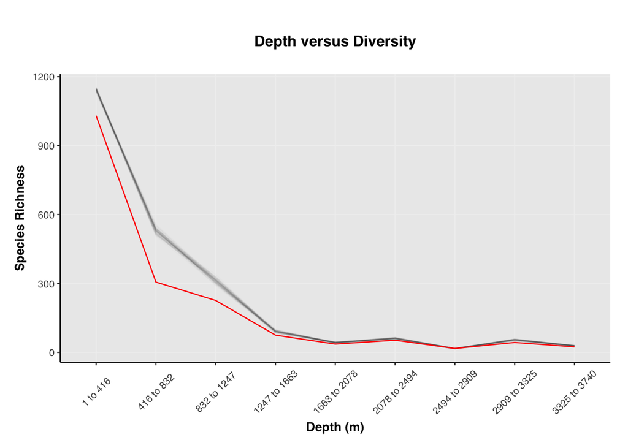

```r
calcEffortAndAlpha <-function(rawData){
  effortAndAlpha <- data.frame(table(rawData$data$SOcurated_depthBin))
  for(i in 1:nrow(effortAndAlpha)){
    binCommunity <- rawData$data[rawData$data$SOcurated_depthBin == effortAndAlpha$Var1[i],]
    binCommunity <- binCommunity[complete.cases(binCommunity$SOcurated_depthBin),]
    effortAndAlpha$alpha[i] <- length(unique(binCommunity$WoRMS_scientificName))
  }
  colnames(effortAndAlpha) <- c("Depth", "Count", "Species_Richness")
  return(effortAndAlpha)
}

# Simulate data
fishDatSim <- tenPerBin
fishDatSim$data <- fishDatSim$data[!is.na(fishDatSim$data$SOcurated_depthBin),]
fishDatSim <- lapply(1:100, FUN = function(x) {
    fishDatSim$data$SOcurated_depthBin <- sample(fishDatSim$data$SOcurated_depthBin)
    return(fishDatSim)
  })
# Calculate species richness
allDat <- lapply(fishDatSim,
                 FUN = function(x) calcEffortAndAlpha(x))

effortAndAlpha <-calcEffortAndAlpha(tenPerBin)

# Plot sims and obs
P1 <- ggplot()
medProp <- c()
for(dat in allDat){
  P1 <- P1 +
    geom_line(data = dat, aes(x = Depth, y = Species_Richness, group = 1),
              alpha=0.01)
  medProp <- c(medProp, median(dat$prop))
}

finalPlot <- P1 +
  geom_line(data = effortAndAlpha,
            aes(x = Depth, y = Species_Richness, group = 1),
            col = "red") +
  theme_Publication() +
  labs( x = "Depth (m)", y = "Species Richness") +
  theme(axis.text.x = element_text(angle = 45, hjust=.5,
                                   vjust = .5)) +
  ggtitle("Depth versus Diversity")

finalPlot
```

```r
ggsave("Figures/DiversityObsVsSimGOM.png",finalPlot,height = 8.7, width = 11.4, units = "cm")
```

## Possible correlates with species richness

### Extracting the data

First, we extract the species richness and record counts for each depth bin in each hexagon.

```r
breaks <- tenPerBin$breaks
effortAndAlpha3D <- NULL
for(i in 2:length(breaks)){
  temp <- fishData %>%
    filter(SOcurated_depth >= breaks[i-1], breaks[i] >= SOcurated_depth) %>%
    group_by(hexID) %>%
    summarise(alpha = n_distinct(WoRMS_scientificName), count = n())

  effortAndAlpha3D <- rbind(effortAndAlpha3D,
                      data.frame(temp, depthBin = paste(round(breaks[i-1]), "to",
                                               round(breaks[i]))))
}
```

### Extracting environmental correlates

It was suggested by Katherine Richardson, Owens’s colleague at the University of Copenhagen, that the bump in the diversity decay curve could be the result of thermoclines and/or pycnoclines. We used temperature and salinity data from the World Ocean Atlas 2018 dataset to investigate this idea, extracting mean temperature and salinity for each depth bin within each hexagon. We also examined apparent oxygen utilization and nitrogen concentration as potential correlates.

```r
# Define extraction function
envDatExtract <- function(envRaster, mShp, breaks){
  # Get all the points
  dummyOccs <- data.frame(0, 0, 0)
  colnames(dummyOccs) <- c("longitude", "latitude", "depth")
  catData <- NULL
  for(i in 1:length(mShp)){
    grid <- mSampling3D(occs = dummyOccs,
                        envBrick = envRaster,
                        mShp = mShp[i], verbose = F)
    allData <- cbind(grid,
                     xyzSample(grid, envBrick = envRaster, verbose = F))
    colnames(allData) <- c("longitude", "latitude", "depth", "Variable")

    # Assign points to bins and calculate summary stats
    sumData <- NULL
    for(j in 2:length(breaks)){
      temp <- allData %>% filter(depth >= breaks[j-1], breaks[j] >= depth)
      sumData <- rbind(sumData,
                       data.frame(Variable = mean(temp$Variable),
                                  depthBin = paste(round(breaks[j-1]), "to",
                                                round(breaks[j]))))
    }
    catData <- rbind(catData, data.frame(hexID = i, sumData))
  }
  return(catData)
}

envtData <- rast("~/Dropbox/DeepFishOccurrences/data/EnvironmentalData/ProcessedEnvtData/temperature.tif") %>%
  project(crs(gomShapefile)) %>%
  crop(gomShapefile) %>%
  mask(mask = gomShapefile) %>%
  envDatExtract(mShp = GOM, breaks = tenPerBin$breaks)
```

```
## |---------|---------|---------|---------|=========================================
```

```r
colnames(envtData) <- c("hexID", "Temperature", "depthBin")

envtData <- merge(envtData, rast("~/Dropbox/DeepFishOccurrences/data/EnvironmentalData/ProcessedEnvtData/salinity.tif")  %>%
  project(crs(gomShapefile)) %>%
  crop(gomShapefile) %>%
  mask(mask = gomShapefile) %>%
  envDatExtract(mShp = GOM, breaks = tenPerBin$breaks))
```

```
## |---------|---------|---------|---------|=========================================
```

```r
colnames(envtData)[ncol(envtData)] <- "Salinity"

envtData <- merge(envtData,
                  rast("~/Dropbox/DeepFishOccurrences/data/EnvironmentalData/ProcessedEnvtData/AOU.tif") %>%
  project(crs(gomShapefile)) %>%
  crop(gomShapefile) %>%
  mask(mask = gomShapefile) %>%
  envDatExtract(mShp = GOM, breaks = tenPerBin$breaks))
```

```
## |---------|---------|---------|---------|=========================================
```

```r
colnames(envtData)[ncol(envtData)] <- "AOU"

envtData <- merge(envtData,
                  rast("~/Dropbox/DeepFishOccurrences/data/EnvironmentalData/ProcessedEnvtData/nitrate.tif") %>%
  project(crs(gomShapefile)) %>%
  crop(gomShapefile) %>%
  mask(mask = gomShapefile) %>%
  envDatExtract(mShp = GOM, breaks = tenPerBin$breaks))
```

```
## |---------|---------|---------|---------|=========================================
```

```r
colnames(envtData)[ncol(envtData)] <- "Nitrate"

envtData$maxBinDepth <- as.numeric(unlist(strsplit(as.character(envtData$depthBin),
                                                         " "))[seq(from = 3,
                                                                   to = nrow(envtData) * 3,
                                                                   by = 3)])
mergedData <- merge(envtData, effortAndAlpha3D[,c(1,4,2,3)])
```

Once the data were extracted, we modeled species richness within each depth bin within each hexagon as a function of the number of records, depth, temperature, salinty, AOU, and nitrate. Given the extreme right skew of the data, we used a Poisson distribution. Temperature, salinity, and nitrate had strong variance inflation factors. Once these variables were removed, there was a strong positive correlation between species richness and counts, and a weak negative correlation between species richness and the maximum depth of the bin (both statistically significant).

```r
richnessModel <- glm(data = mergedData, alpha ~ maxBinDepth + count + Temperature + Salinity + AOU + Nitrate, poisson(link="identity"))
summary(richnessModel)
```

```
##
## Call:
## glm(formula = alpha ~ maxBinDepth + count + Temperature + Salinity +
##     AOU + Nitrate, family = poisson(link = "identity"), data = mergedData)
##
## Coefficients:
##               Estimate Std. Error z value Pr(>|z|)
## (Intercept) -2.360e+01  5.248e+01  -0.450   0.6529
## maxBinDepth -1.470e-03  3.682e-04  -3.992 6.55e-05 ***
## count        3.250e-01  4.640e-03  70.048  < 2e-16 ***
## Temperature -2.422e-02  1.517e-01  -0.160   0.8732
## Salinity     9.029e-01  1.508e+00   0.599   0.5494
## AOU         -2.681e-02  1.532e-02  -1.750   0.0801 .
## Nitrate      7.513e-02  8.843e-02   0.850   0.3955
## ---
## Signif. codes:  0 '***' 0.001 '**' 0.01 '*' 0.05 '.' 0.1 ' ' 1
##
## (Dispersion parameter for poisson family taken to be 1)
##
##     Null deviance: 12899.3  on 286  degrees of freedom
## Residual deviance:  1705.8  on 280  degrees of freedom
##   (5 observations deleted due to missingness)
## AIC: 2921.7
##
## Number of Fisher Scoring iterations: 10
```

```r
vif(richnessModel)
```

```
## maxBinDepth       count Temperature    Salinity         AOU     Nitrate
##    7.970252    1.091149   37.681077   18.023556   10.951979   15.146367
```

```r
richnessModel <- glm(data = mergedData, alpha ~ maxBinDepth + count + AOU,
                     poisson(link="identity"))
summary(richnessModel)
```

```
##
## Call:
## glm(formula = alpha ~ maxBinDepth + count + AOU, family = poisson(link = "identity"),
##     data = mergedData)
##
## Coefficients:
##               Estimate Std. Error z value Pr(>|z|)
## (Intercept)  8.5545029  0.5604242  15.264  < 2e-16 ***
## maxBinDepth -0.0014969  0.0001363 -10.980  < 2e-16 ***
## count        0.3248283  0.0046263  70.213  < 2e-16 ***
## AOU         -0.0179797  0.0048181  -3.732  0.00019 ***
## ---
## Signif. codes:  0 '***' 0.001 '**' 0.01 '*' 0.05 '.' 0.1 ' ' 1
##
## (Dispersion parameter for poisson family taken to be 1)
##
##     Null deviance: 12899.3  on 286  degrees of freedom
## Residual deviance:  1706.7  on 283  degrees of freedom
##   (5 observations deleted due to missingness)
## AIC: 2916.6
##
## Number of Fisher Scoring iterations: 10
```

```r
vif(richnessModel)
```

```
## maxBinDepth       count         AOU
##    1.091294    1.084796    1.080223
```

```r
convenienceEffect <- lm(data = mergedData, count ~ maxBinDepth)
summary(convenienceEffect)
```

```
##
## Call:
## lm(formula = count ~ maxBinDepth, data = mergedData)
##
## Residuals:
##     Min      1Q  Median      3Q     Max
## -100.21  -78.52  -42.34   15.17 1528.79
##
## Coefficients:
##              Estimate Std. Error t value Pr(>|t|)
## (Intercept) 119.91214   15.01989   7.984 3.35e-14 ***
## maxBinDepth  -0.04495    0.01032  -4.357 1.84e-05 ***
## ---
## Signif. codes:  0 '***' 0.001 '**' 0.01 '*' 0.05 '.' 0.1 ' ' 1
##
## Residual standard error: 170 on 290 degrees of freedom
## Multiple R-squared:  0.06143,    Adjusted R-squared:  0.05819
## F-statistic: 18.98 on 1 and 290 DF,  p-value: 1.835e-05
```

### Plotting

Finally, we plot alpha diversity and its hypothesized correlates to identify emergent trends.

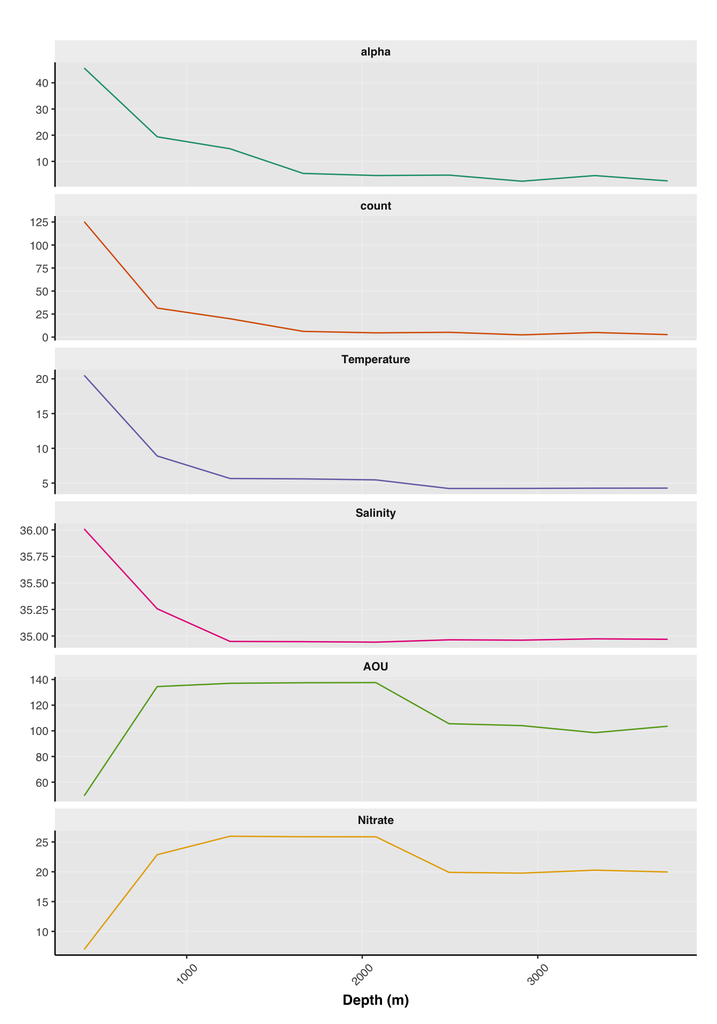

```r
effortAndAlphaLong <- reshape2::melt(mergedData[,c("maxBinDepth", "alpha",
                                                   "count","Temperature",
                                                   "Salinity","AOU", "Nitrate")],
                                      id.vars = "maxBinDepth")
effortAndAlphaLong <- aggregate(effortAndAlphaLong, value ~ maxBinDepth + variable, mean)

P1 <- ggplot(effortAndAlphaLong, aes(maxBinDepth, value,
                             colour = variable, group = 1)) +
  geom_line() +
  theme_Publication() +
  labs( x = "Depth (m)") +
  theme(axis.text.x = element_text(angle = 45, hjust=.5, vjust = .5)) +
  scale_color_brewer(palette = "Dark2") +
  facet_wrap(variable~., ncol = 1, scales = "free_y") +
  theme(legend.position="none", axis.title.y = element_blank())
P1
```

```r
ggsave("Figures/GOMClines.png",P1,height = 22.5, width = 8.7, units = "cm")
```

# Summary statistics

Finally, here are some sampling stats.

```
## [1] "There are 1241 species in the GOM dataset."
```

```
## [1] "There are 232 cells in the GOM dataset."
```

```
## [1] "140 cells in the GOM dataset have at least 10 records."
```

```
## [1] "58 cells in the GOM dataset have at least 100 records."
```

```
## [1] "154 cells in the GOM dataset have bathymetry at or exceeding 200m."
```

```
## [1] "110 GOM cells (47%) have bathymetry at or exceeding 200m AND have at least one record from at or below 200m."
```

# Appendix: Additional analyses

The following analyses were also initially performed, but were not conclusive enough to include in the final manuscript. We include them here should they prove useful to other researchers with similar questions.

## Cluster analysis

One of the first questions we were interested in addressing with this dataset was whether there was clear community structure with depth. We calculated how similar the species assemblages in each bin were by standardizing the data to a presence/absence matrix, then calculating Chao similarity. The results are plotted as a dendrogram, where shorter branches between tips indicate more similarity between bins.

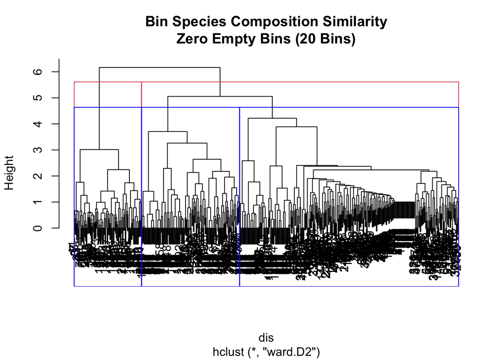

```r
# How do they cluster?
plot(zeroEmpty$clust.res,
     main = paste0("Bin Species Composition Similarity\nZero Empty Bins (",
                   zeroEmpty$binNumber, " Bins)"))
rect.hclust (zeroEmpty$clust.res, k = 2)
rect.hclust (zeroEmpty$clust.res, k = 3, border = "blue")
```

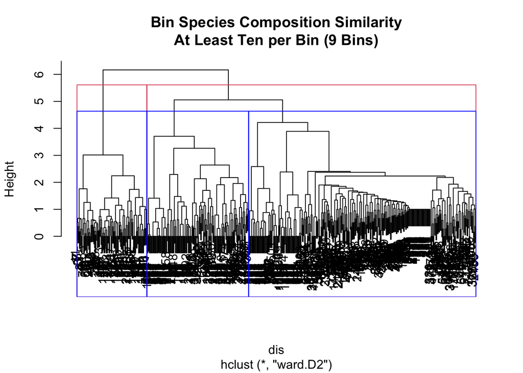

```r
plot(tenPerBin$clust.res,
     main = paste0("Bin Species Composition Similarity\nAt Least Ten per Bin (",
                   tenPerBin$binNumber, " Bins)"))
rect.hclust (tenPerBin$clust.res, k = 2)
rect.hclust (tenPerBin$clust.res, k = 3, border = "blue")
```

Next we take the pairwise similarity scores of the bins, and perform multidimensional scaling so that the distances between points are approximately equal to their dissimilarity.

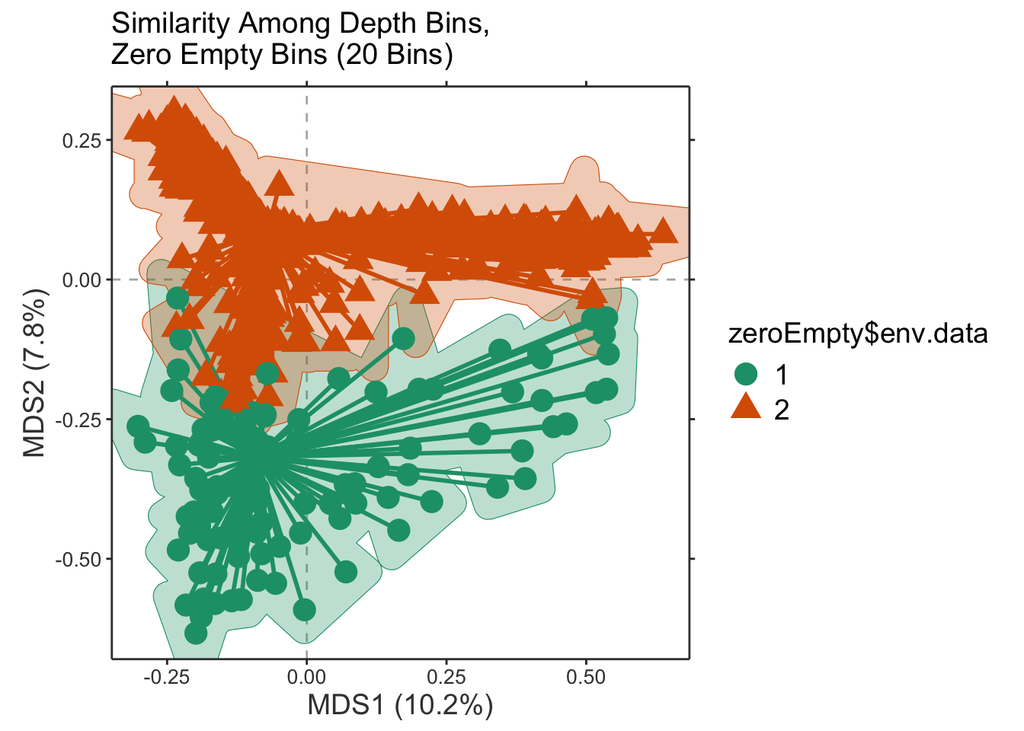

```r
# Ordinate and plot
BioR.theme <- theme(
        panel.background = element_blank(),
        panel.border = element_blank(),
        panel.grid = element_blank(),
        axis.line = element_line("gray25"),
        text = element_text(size = 12),
        axis.text = element_text(size = 10,
                                 colour = "gray25"),
        axis.title = element_text(size = 14,
                                  colour = "gray25"),
        legend.title = element_text(size = 14),
        legend.text = element_text(size = 14),
        legend.key = element_blank())

plotDiversityZeroEmpty <- ggplot() +
    geom_vline(xintercept = c(0), color = "grey70",
               linetype = 2) +
    geom_hline(yintercept = c(0), color = "grey70",
               linetype = 2) +
    xlab(zeroEmpty$axis.long[1, "label"]) +
    ylab(zeroEmpty$axis.long[2, "label"]) +
    scale_x_continuous(sec.axis = dup_axis(labels=NULL,
                                           name=NULL)) +
    scale_y_continuous(sec.axis = dup_axis(labels=NULL,
                                           name=NULL)) +
    geom_mark_hull(data=zeroEmpty$sites.long,
                   aes(x=axis1, y=axis2,
                       colour=zeroEmpty$env.data,
                       fill=after_scale(alpha(colour, 0.2))),
                   concavity=0.1, linewidth=0.2, show.legend=FALSE) +
    geom_segment(data=zeroEmpty$centroids.long,
                 aes(x=axis1c, y=axis2c, xend=axis1,
                     yend=axis2, colour=zeroEmpty$env.data),
                 linewidth=1, show.legend=FALSE) +
    geom_point(data=zeroEmpty$sites.long,
               aes(x=axis1, y=axis2, colour=zeroEmpty$env.data,
                   shape=zeroEmpty$env.data),
               size=5) +
    ggtitle(paste0("Similarity Among Depth Bins,\nZero Empty Bins (",
                   zeroEmpty$binNumber, " Bins)")) +
    BioR.theme +
    scale_colour_brewer(type = "qual", palette = "Dark2") +
    coord_fixed(ratio=1)

plotDiversityTenPerBin <- ggplot() +
    geom_vline(xintercept = c(0), color = "grey70", linetype = 2) +
    geom_hline(yintercept = c(0), color = "grey70", linetype = 2) +
    xlab(tenPerBin$axis.long[1, "label"]) +
    ylab(tenPerBin$axis.long[2, "label"]) +
    scale_x_continuous(sec.axis = dup_axis(labels=NULL, name=NULL)) +
    scale_y_continuous(sec.axis = dup_axis(labels=NULL, name=NULL)) +
    geom_mark_hull(data=tenPerBin$sites.long,
                   aes(x=axis1, y=axis2, colour=tenPerBin$env.data,
                       fill=after_scale(alpha(colour, 0.2))),
                   concavity=0.1, linewidth=0.2, show.legend=FALSE) +
    geom_segment(data=tenPerBin$centroids.long,
                 aes(x=axis1c, y=axis2c, xend=axis1, yend=axis2,
                     colour=tenPerBin$env.data),
                 linewidth    =1, show.legend=FALSE) +
    geom_point(data=tenPerBin$sites.long,
               aes(x=axis1, y=axis2, colour=tenPerBin$env.data,
                   shape=tenPerBin$env.data),
               size=5) +
    ggtitle(paste0("Similarity Among Depth Bins,\nAt Least Ten per Bin (",
                   tenPerBin$binNumber, " Bins)")) +
    BioR.theme +
    scale_colour_brewer(type = "qual", palette = "Dark2") +
    coord_fixed(ratio=1)

plotDiversityZeroEmpty
```

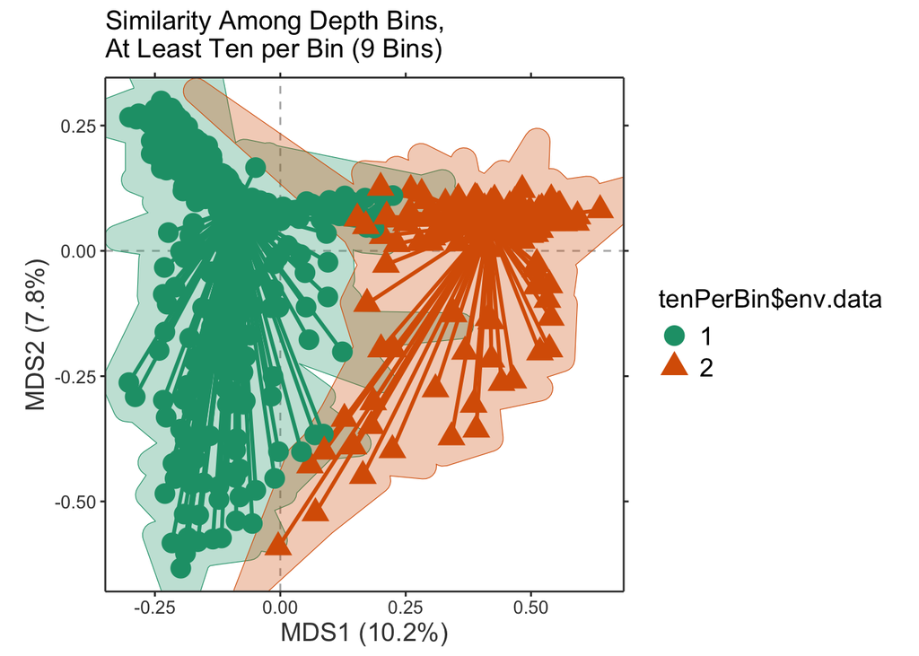

```r
plotDiversityTenPerBin
```

Both bin schemes show two distinct clusters. Which bins are in these groups?!

```
## [1] "Cluster identities for each bin, no empty bins are permitted:"
```

```
##      [,1]
## 1       2
## 2       2
## 3       2
## 4       2
## 5       2
## 6       2
## 7       2
## 8       2
## 9       2
## 10      2
## 11      2
## 12      2
## 13      2
## 14      2
```

[output cut: 539 more lines]

```
## [1] "Cluster identities for each bin, minimum of ten records per bin:"
```

```
##      [,1]
## 1       1
## 2       1
## 3       1
## 4       2
## 5       1
## 6       2
## 7       2
## 8       1
## 9       2
## 10      2
## 11      2
## 12      2
## 13      2
## 14      2
```

[output cut: 539 more lines]

## Identity test

Finally, are there any species that clearly and signifcantly associate with one or the other of the depth clusters we have identified? To to this, we use `multipatt()`, an implementation of metrics developed in De Cáceres and Legendre (2009).

```r
tenPerBin$spClusters[tenPerBin$spClusters$p.value < 0.01,]
```

```
##                               s.1 s.2 index      stat p.value
## Ablennes hians                  1   0     1 0.1858628   0.005
## Abudefduf saxatilis             1   0     1 0.1358472   0.005
## Acanthemblemaria aspera         1   0     1 0.1934765   0.005
## Acanthostracion quadricornis    1   0     1 0.4573972   0.005
## Acanthurus bahianus             1   0     1 0.1786474   0.005
## Acanthurus chirurgus            1   0     1 0.1450953   0.005
## Acanthurus coeruleus            1   0     1 0.2205644   0.005
## Achirus lineatus                1   0     1 0.2259090   0.005
## Ahlia egmontis                  1   0     1 0.2587241   0.005
## Albula vulpes                   1   0     1 0.1694232   0.005
## Aluterus heudelotii             1   0     1 0.1915588   0.005
## Aluterus schoepfii              1   0     1 0.2727474   0.005
## Amblycirrhitus pinos            1   0     1 0.1626500   0.005
## Anarchias similis               1   0     1 0.2216763   0.005
## Anarchopterus criniger          1   0     1 0.1253268   0.005
## Anchoa cubana                   1   0     1 0.2073903   0.005
## Anchoa hepsetus                 1   0     1 0.3484068   0.005
## Anchoa lyolepis                 1   0     1 0.1526056   0.005
## Anchoa mitchilli                1   0     1 0.2679985   0.005
## Ancylopsetta dilecta            1   0     1 0.3825452   0.005
## Ancylopsetta quadrocellata      1   0     1 0.2788867   0.005
## Anisotremus virginicus          1   0     1 0.1786474   0.005
## Antennarius striatus            1   0     1 0.1993583   0.005
## Apogon aurolineatus             1   0     1 0.1849152   0.005
## Apogon binotatus                1   0     1 0.1786474   0.005
## Apogon maculatus                1   0     1 0.2451720   0.005
## Apogon planifrons               1   0     1 0.1626500   0.005
## Apogon pseudomaculatus          1   0     1 0.3798398   0.005
## Apogon townsendi                1   0     1 0.2073903   0.005
## Archosargus probatocephalus     1   0     1 0.1626500   0.005
## Ariopsis felis                  1   0     1 0.2788867   0.005
## Ariosoma anale                  1   0     1 0.1520371   0.005
## Ariosoma balearicum             1   0     1 0.3178550   0.005
## Astrapogon puncticulatus        1   0     1 0.1786474   0.005
## Astroscopus ygraecum            1   0     1 0.1450953   0.005
## Atherinomorus stipes            1   0     1 0.1626500   0.005
## Aulostomus maculatus            1   0     1 0.2073903   0.005
## Auxis rochei                    1   0     1 0.1993583   0.005
## Auxis thazard                   1   0     1 0.2129730   0.005
```

[output cut: 329 more lines]

```
## Trachinotus carolinus           1   0     1 0.1450953   0.005
## Trachurus lathami               1   0     1 0.5471617   0.005
## Trichiurus lepturus             1   0     1 0.4021305   0.005
## Trichopsetta ventralis          1   0     1 0.4214280   0.005
## Trinectes maculatus             1   0     1 0.2567763   0.005
## Umbrina coroides                1   0     1 0.1253268   0.005
## Upeneus parvus                  1   0     1 0.4373204   0.005
## Uroconger syringinus            1   0     1 0.3498721   0.005
## Urophycis cirrata               1   0     1 0.1484127   0.005
## Urophycis floridana             1   0     1 0.4681001   0.005
## Urophycis regia                 1   0     1 0.1858628   0.005
## Uropterygius macularius         1   0     1 0.1694340   0.005
## Xenomystax congroides           1   0     1 0.1849152   0.005
## Xyrichtys novacula              1   0     1 0.2451720   0.005
## Zalieutes mcgintyi              1   0     1 0.2432149   0.005
```

## Depth ranges

First, how do these data look?

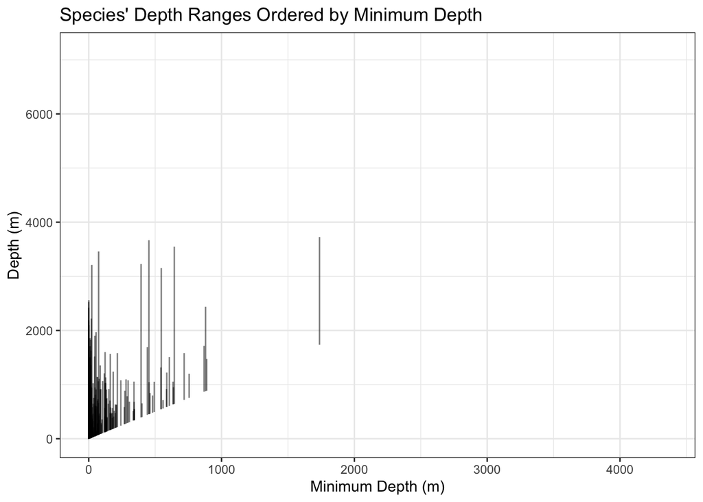

```r
depthRanges <- fishData %>%
  group_by(WoRMS_scientificName) %>%
  summarise(count = n(),
            depthMin=quantile(SOcurated_minimumDepthInMeters, probs = .05),
            depthMax=quantile(SOcurated_maximumDepthInMeters, probs = .95),
            family = WoRMS_family[1])
depthRanges <- depthRanges %>%
  filter(count > 9) %>%
  mutate(depthRange = depthMax - depthMin) %>%
  arrange(depthMin, depthMax, family)

ggplot()+
  xlab("Minimum Depth (m)") +
  ylab("Depth (m)") +
  labs(title = "Species' Depth Ranges Ordered by Minimum Depth") +
  theme(plot.caption = element_text(hjust=1)) +
  #geom_hline(aes(yintercept = c(200,1000), col = "darkred"), lty = "dashed", show.legend = F) +
  #geom_vline(aes(xintercept = c(200,1000), col = "darkred"), lty = "dashed", show.legend = F) +
  geom_linerange(data=depthRanges,
                  aes(x=depthMin,
                      ymin=depthMin,
                      ymax=depthMax),
                  linewidth=.5, alpha=0.5) +
  scale_x_continuous(limits = c(0, 4350)) +
  scale_y_continuous(limits = c(0, 7150)) +
  theme_bw()
```

And here is a statistical test.

```r
# linear model controlling for sampling
model <- lm(data = depthRanges, depthRange ~ depthMin + count)

summary(model)
```

```
##
## Call:
## lm(formula = depthRange ~ depthMin + count, data = depthRanges)
##
## Residuals:
##     Min      1Q  Median      3Q     Max
## -781.97 -296.97 -187.08   96.57 2949.87
##
## Coefficients:
##             Estimate Std. Error t value Pr(>|t|)
## (Intercept) 370.4342    35.2114  10.520  < 2e-16 ***
## depthMin      1.0459     0.1510   6.925 1.39e-11 ***
## count        -1.3723     0.6308  -2.175   0.0301 *
## ---
## Signif. codes:  0 '***' 0.001 '**' 0.01 '*' 0.05 '.' 0.1 ' ' 1
##
## Residual standard error: 515.2 on 484 degrees of freedom
## Multiple R-squared:  0.1062, Adjusted R-squared:  0.1025
## F-statistic: 28.76 on 2 and 484 DF,  p-value: 1.573e-12
```

# Bibliography of citations provided

```r
print(sort(unique(fishData$SOcurated_bibliographicCitation)))
```

```
##  [1] "De la Cruz-Agüero J. 2012. Registros ictiofaunísticos de localidades selectas de 10 regiones marinas prioritarias del Pacífico Mexicano. Centro Interdisciplinario de Ciencias Marinas. Instituto Politécnico Nacional. Bases de datos SNIB-CONABIO, proyectos EC013, DC028, BA005, V049, T028, K05…
##  [2] "Escobar-Briones E. G. 2006. Base de datos de fauna batial, abisopelágica y abisal del Golfo de México. Instituto de Ciencias del Mar y Limnología. Universidad Nacional Autónoma de México. Bases de datos SNIB-CONABIO, proyecto BE013. México, D. F."
##  [3] "Espinosa-Pérez H. 2002. Computarización de la Colección Nacional de Peces del Instituto de Biología UNAM. Colección CNPE. Instituto de Biología. Universidad Nacional Autónoma de México. Bases de datos SNIB-CONABIO, proyecto T023. México, D. F."
##  [4] "Flores-Coto C. 2002. Base de datos sobre ictioplancton para la Bahía de Campeche, México. Instituto de Ciencias del Mar y Limnología. Universidad Nacional Autónoma de México. Bases de datos SNIB-CONABIO, proyecto S109. México, D. F."
##  [5] "http://ipt.vertnet.org:8080/ipt/resource.do?r=sio_marine_vertebrates."
##  [6] "NCSM [catalogNumber] - North Carolina Museum of Natural Sciences Ichthyology Collection"
##  [7] "University of Alabama Ichthyology Collection. http://ipt.vertnet.org:8080/ipt/resource.do?r=uaic_fish."
##  [8] "urn:catalog:TCWC:Ichthyology. http://ipt.vertnet.org:8080/ipt/resource?r=tcwc_verts."
##  [9] "Vega-Cendejas M. E. 2005. Evaluación de la ictiofauna en las áreas focales del corredor biológico Unidad Mérida. Centro de Investigación y de Estudios Avanzados. Instituto Politécnico Nacional. Bases de datos SNIB-CONABIO, proyecto Y027. México, D. F."
## [10] "Vega-Cendejas M. E. 2007. Contribución a la riqueza ictiofaunística de la Reserva de Ría Lagartos, Yucatán. Unidad Mérida. Centro de Investigación y de Estudios Avanzados. Instituto Politécnico Nacional. Bases de datos SNIB-CONABIO, proyecto BK026. México, D. F."
## [11] "YPM ICH"
```